# Neuropathic pain

### By: Yael Rosen Lang

# Introduction

This study’s goal is to investigate aspects of well being, health and pain in children and teenagers with neuropathic pain.

# Data preparation

The data set consisted of 309 subjects. It was imported from excel to R (R Core Team (2020). R: A language and environment for statistical computing. R Foundation for Statistical Computing, Vienna, Austria. URL https://www.R-project.org/.) The data originated from 2 sources: CHOP and CCHMC. One subject was labeled as being part of the CHOP data set, although its study code and data collection characteristics indicated it was part of the CCHMC data set. The labeling was corrected. There were 171 subjects from the CCHMC source and 138 from the CHOP source.

## Missing data

There were discrepancies in data collection between the CCMHC and the CHOP data sources. Subjects from the CCHMC source (171 out of 309 subjects, 55% of participants) had only basic demographic data (age and gender). For these subjects there was missing data for race, education, habitat and demographic information regarding the child’s parent or guardian. In addition, CCHMC subjects had no information regarding comorbidities. Visual pain map variables (selecting painful body parts on a front and back body map) had 12% and 22% missing data, respectively. There was also a discrepancy in missing data rates between diagnoses groups, and for these reasons these variables were not used in the analysis. All other parameters had a negligible rate of missing data.

The data was screened for out-of-range values, un-trusted values, data entry and formatting errors and inconsistencies. For the JIA type parameter, levels “undifferentiated” and “other” were unified due to a small number of observations (10 and 2 respectively).

# Sample description

The sample was described using the demographic and clinical parameters for which complete data was available. A comparison between the 2 data sets was performed using t-tests and Chi-square tests, to determine whether we can use the CHOP demographic data for analysis and extrapolate the conclusions for the entire data set.

|  | CHOP (N=138) | CCHMC (N=171) | P-value |
| --- | --- | --- | --- |
| Gender |  |  |  |
| Male | 28 (20.3%) | 38 (22.2%) | 0.785 |
| Female | 110 (79.7%) | 133 (77.8%) |  |
| Age |  |  |  |
| Mean (SD) | 14.3 (2.42) | 13.4 (2.89) | 0.003 |
| Median [Min, Max] | 15.0 [8.00, 19.0] | 14.0 [8.00, 18.0] |  |
| Time from diagnosis(years) |  |  |  |
| Mean (SD) | 2.36 (1.99) | 4.06 (3.72) | <0.001 |
| Median [Min, Max] | 2.00 [0, 10.0] | 3.00 [0, 16.0] |  |
| Missing | 1 (0.7%) | 0 (0%) |  |
| Diagnosis |  |  |  |
| Chronic pain condition | 96 (69.6%) | 53 (31.0%) | <0.001 |
| JIA | 42 (30.4%) | 118 (69.0%) |  |
| JIA type |  |  |  |
| Not applicable | 94 (68.1%) | 53 (31.0%) | <0.001 |
| Systemic | 2 (1.4%) | 6 (3.5%) |  |
| Psoriatic | 3 (2.2%) | 11 (6.4%) |  |
| Polyarthiritis | 10 (7.2%) | 61 (35.7%) |  |
| Oligoarthritis | 8 (5.8%) | 31 (18.1%) |  |
| Undifferentiated/other | 9 (6.5%) | 3 (1.8%) |  |
| Enthesis | 11 (8.0%) | 6 (3.5%) |  |
| Missing | 1 (0.7%) | 0 (0%) |  |
| Global health |  |  |  |
| Excellent | 24 (17.4%) | 37 (21.6%) | 0.242 |
| Very good | 42 (30.4%) | 47 (27.5%) |  |
| Good | 45 (32.6%) | 52 (30.4%) |  |
| Fair | 15 (10.9%) | 28 (16.4%) |  |
| Poor | 11 (8.0%) | 6 (3.5%) |  |
| Missing | 1 (0.7%) | 1 (0.6%) |  |

The two data sets are similar in gender ratios and global health, but are dissimilar in the subjects’ distribution of age, time from diagnosis, diagnosis (JIA/chronic pain) and JIA type. We therefore can only rely on the parameters for which we have full data to describe our sample.

|  | Total (N=309) |
| --- | --- |
| Gender |  |
| Male | 66 (21.4%) |
| Female | 243 (78.6%) |
| Age |  |
| Mean (SD) | 13.8 (2.73) |
| Median [Min, Max] | 14.0 [8.00, 19.0] |
| Time from diagnosis(years) |  |
| Mean (SD) | 3.31 (3.18) |
| Median [Min, Max] | 2.00 [0, 16.0] |
| Missing | 1 (0.3%) |
| Diagnosis |  |
| Chronic pain condition | 149 (48.2%) |
| JIA | 160 (51.8%) |
| JIA type |  |
| Not applicable | 147 (47.6%) |
| Systemic | 8 (2.6%) |
| Psoriatic | 14 (4.5%) |
| Polyarthiritis | 71 (23.0%) |
| Oligoarthritis | 39 (12.6%) |
| Undifferentiated/other | 12 (3.9%) |
| Enthesis | 17 (5.5%) |
| Missing | 1 (0.3%) |
| Global health |  |
| Excellent | 61 (19.7%) |
| Very good | 89 (28.8%) |
| Good | 97 (31.4%) |
| Fair | 43 (13.9%) |
| Poor | 17 (5.5%) |
| Missing | 2 (0.6%) |

**Gender**- The majority of our sample is female (79%). **Age** ranges between 8 and 19 years, with a mean and median of 14 years (mean’s SD=2.72 y.).

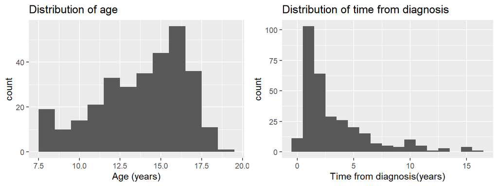

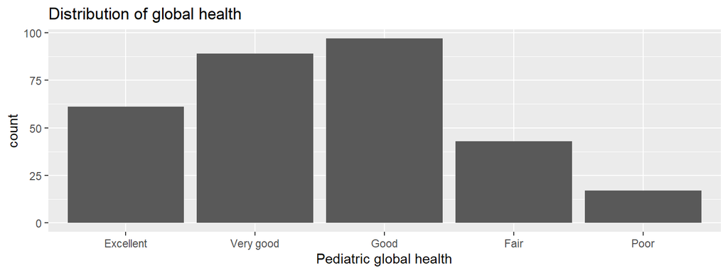

**Global health**-most of the subjects are in good to excellent health.

Data regarding **comorbidities** was available for the CHOP data source only (138 out of 309 subjects), and is described in the appendix as an illustration. This data does not represent the entire study population and will not be used in the analysis.

### Summary

# Pain Variables

The following variables were created based on data collected regarding pain characteristics and pain-related scores:

### Widespread pain

This is an aggregating variable, summing up the number of painful body locations selected by the subject.

Widespread pain descriptive statistics

| Min. | 1st Qu. | Median | Mean | 3rd Qu. | Max. |
| --- | --- | --- | --- | --- | --- |
| 0 | 3 | 6 | 12.95 | 18 | 61 |

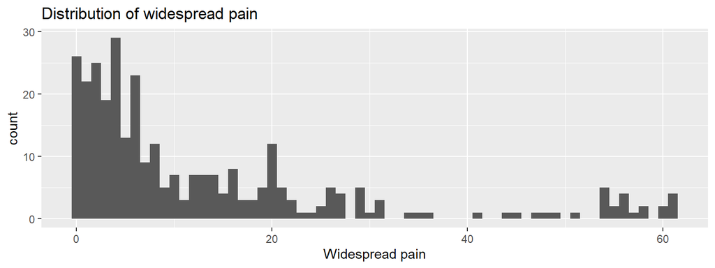

### Pain behavior

This is the average score on a 48-item questionnaire regarding the influence of pain on daily behavior (ranging 0-5).

Pain behavior descriptive statistics

| Min. | 1st Qu. | Median | Mean | 3rd Qu. | Max. |
| --- | --- | --- | --- | --- | --- |
| 0.1 | 1.56 | 2.21 | 2.15 | 2.81 | 4.29 |

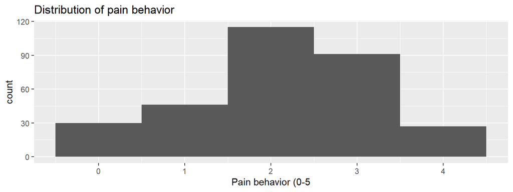

### Pain catastrophizing scale

This is the average score on a 13-item questionnaire assessing catastrophic thinking related to pain (ranging 0-4).

Pain catastrophizing scale descriptive statistics

| Min. | 1st Qu. | Median | Mean | 3rd Qu. | Max. |
| --- | --- | --- | --- | --- | --- |
| 0 | 0.38 | 1 | 1.3 | 2.08 | 4 |

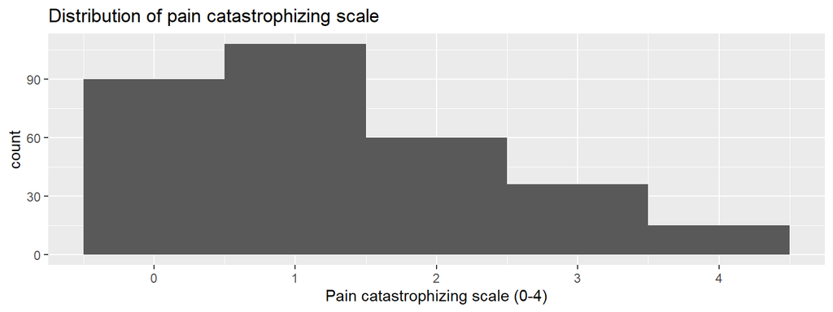

### Pain intensity 1 (range 0 to 10)

This is the average score on an 4-item questionnaire regarding pain intensity (ranging 0-10).

Pain intensity 1 (0-10) descriptive statistics

| Min. | 1st Qu. | Median | Mean | 3rd Qu. | Max. |
| --- | --- | --- | --- | --- | --- |
| 0 | 1.75 | 3.75 | 3.89 | 6 | 10 |

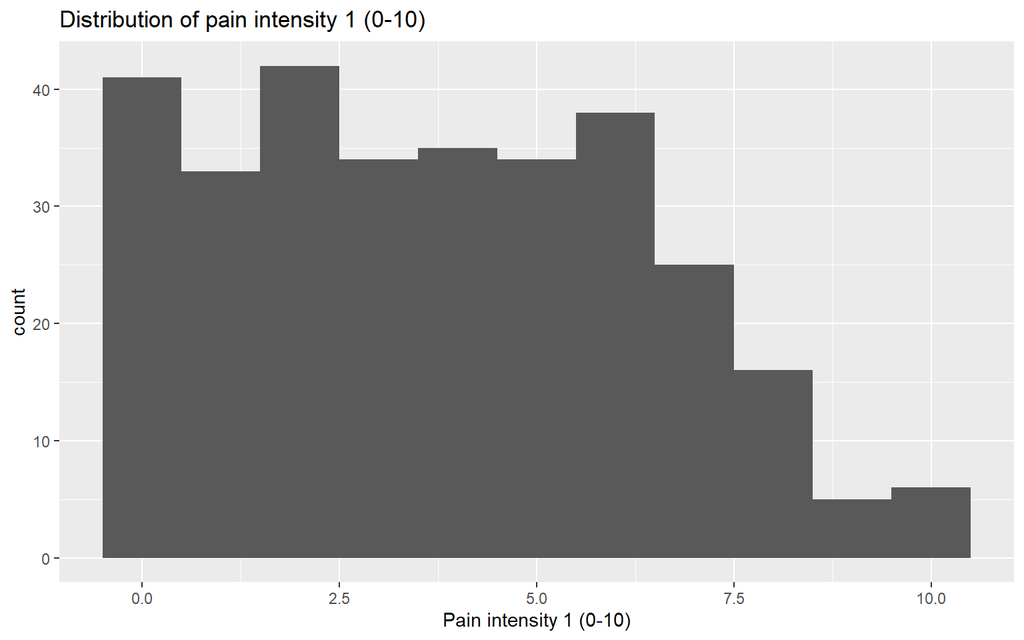

### Pain intensity 2 (range 0 to 4)

This is the average score on an 3-item questionnaire regarding pain intensity (ranging 0-4).

Pain intensity 2 (0-4) descriptive statistics

| Min. | 1st Qu. | Median | Mean | 3rd Qu. | Max. |
| --- | --- | --- | --- | --- | --- |
| 0 | 1 | 1.67 | 1.64 | 2.33 | 4 |

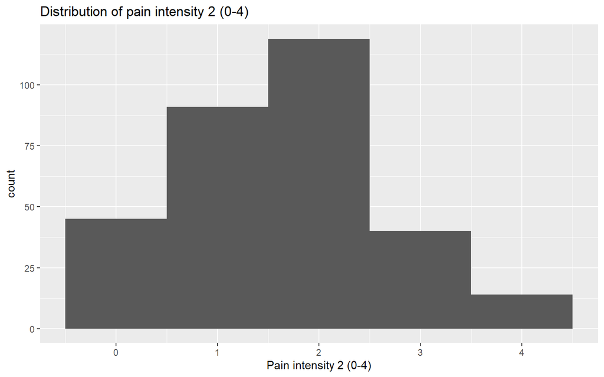

### Pain quality 1 (range 0 to 4)

This is the average score on an 36-item questionnaire regarding pain quality (ranging 0-4).

Pain quality 1 (0-4) descriptive statistics

| Min. | 1st Qu. | Median | Mean | 3rd Qu. | Max. | NA’s |
| --- | --- | --- | --- | --- | --- | --- |
| 0.11 | 0.5 | 1.07 | 1.17 | 1.69 | 3.5 | 1 |

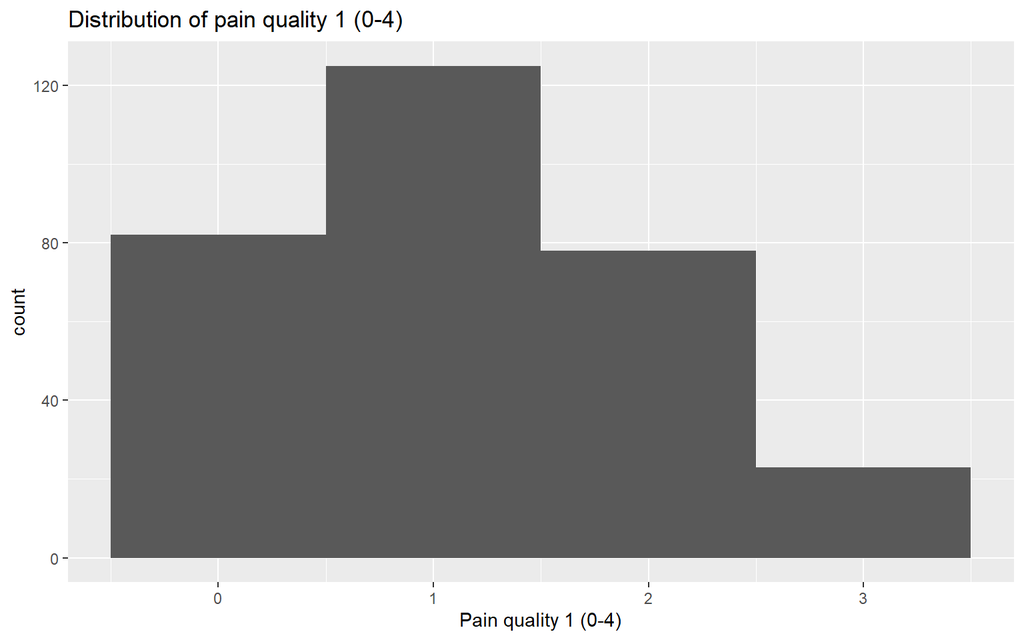

### Pain quality 2 (range 0-1)

This is the average score on an 23-item questionnaire regarding pain quality (response yes/no).

Pain quality 2 (0-1) descriptive statistics

| Min. | 1st Qu. | Median | Mean | 3rd Qu. | Max. |
| --- | --- | --- | --- | --- | --- |
| 0 | 0.17 | 0.43 | 0.46 | 0.78 | 1 |

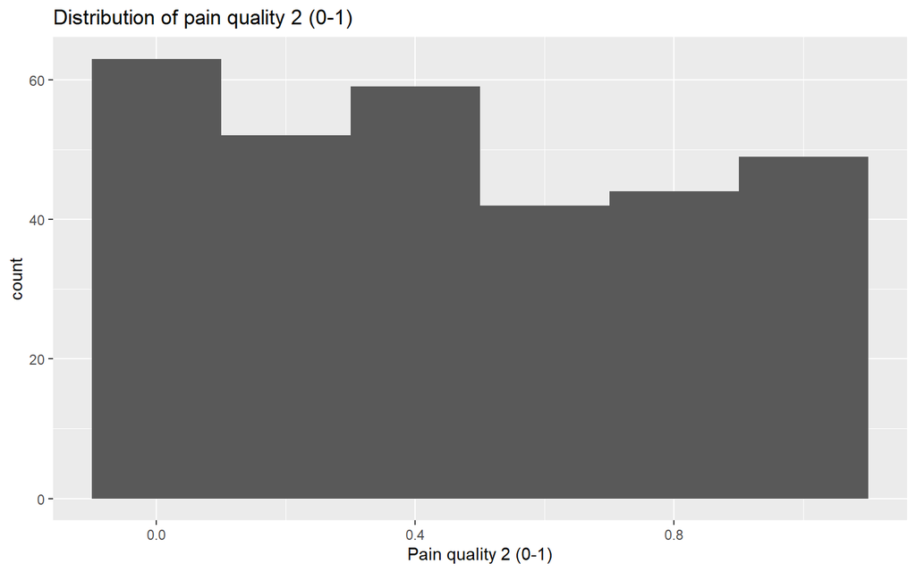

### Summary

Most pain-related parameters (depression, fatigue, pain behavior, etc.) show a right asymmetrical distribution. This means that most of the subjects have low levels of depression, fatigue, etc., and there is a long tail of subjects with high levels.

# 1. Prediction model for global health

Global health is a 5-level response to the question “How would you say your health is?” (0=Excellent, 1=very good, 2= good, 4=fair, 5=poor).

Distribution of Global health

| Excellent | Very good | Good | Fair | Poor |
| --- | --- | --- | --- | --- |
| 61 | 89 | 97 | 43 | 17 |

A model was developed for predicting global health. Two subjects who had missing data for global health were omitted, and our model was based on 307 subjects.

## Predictors

In order to identify possible predictors for our model, the following parameters were examined for their correlation to global health.

### Categorical variables

we’ll take a look at the cross-tabulation of gender and diagnosis with global health.

Health by gender (p-value=0.386, Chi-squared statistic = 4.15)

|  | Excellent | Very good | Good | Fair | Poor |
| --- | --- | --- | --- | --- | --- |
| Male | 17 | 21 | 20 | 6 | 2 |
| Female | 44 | 68 | 77 | 37 | 15 |

Health by diagnosis (p-value<0.001, Chi-squared statistic= 29.15)

|  | Excellent | Very good | Good | Fair | Poor |
| --- | --- | --- | --- | --- | --- |
| Chronic pain condition | 16 | 38 | 50 | 28 | 15 |
| JIA | 45 | 51 | 47 | 15 | 2 |

The correlation between gender and health is not statistically significant. The correlation between health and diagnosis is statistically significant Our outcome variable has 5 levels, some have sparse cell counts (17 observations total for level “5=poor”). Any categorical main effect or interaction in the model could result in empty or near-empty cells. In order to keep our model stable and valid it is best not to use these categorical predictors in our prediction models.

### Continuous variables

We will examine possible continuous predictors and look for distribution differences between the 5 levels of global health. A good predictor is one for which the distributions of different levels have minimal overlap, enabling separation of the levels.

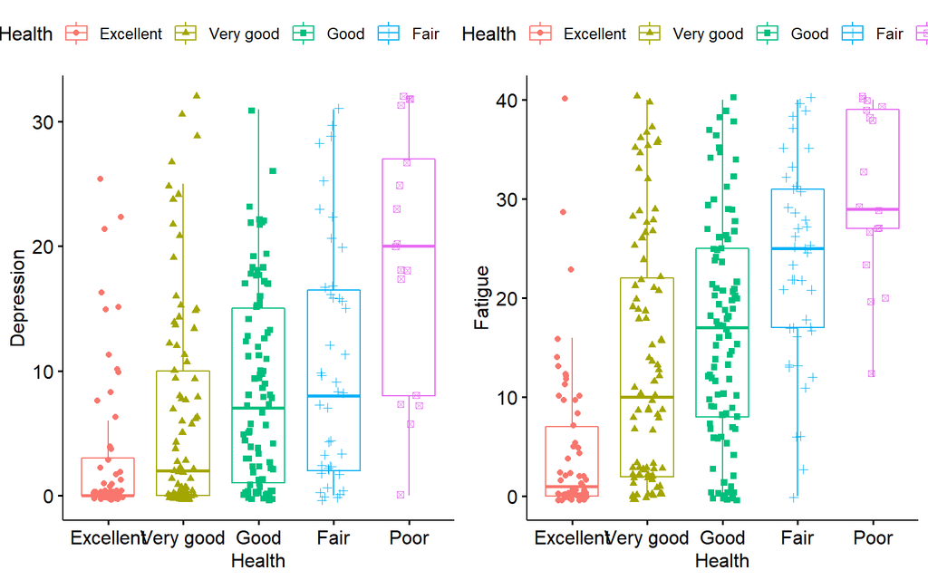

Fatigue (right) would be a better predictor than depression (left), as it has a slightly better separation between levels. Most of our potential predictors have a graph that is somewhere in between depression and fatigue- a positive trend, usually proportional (as we would expect from an ordinal scale) and a lot of overlap between levels due to long tails. Levels “Very good”, “Good” and “Fair” can’t be differentiated in most cases, and we can notice again the scarcity of level “Poor”. This would hamper our model’s accuracy. Most variables act similarly and are possibly correlated, and multicollinearity will be assessed and addressed.

## Ordinal logistic regression models

Global health prediction models

|  | Model 1 |  | Model 2 |  |
| --- | --- | --- | --- | --- |
| Predictors | Odds Ratios | p | Odds Ratios | p |
| Excellent\|Very good | 5.19 | **0.008** | 4.09 | **0.011** |
| Very good\|Good | 28.98 | **<0.001** | 22.60 | **<0.001** |
| Good\|Fair | 181.25 | **<0.001** | 140.25 | **<0.001** |
| Fair\|Poor | 936.48 | **<0.001** | 723.29 | **<0.001** |
| Depression | 1.01 | 0.750 |  |  |
| Fatigue | 1.05 | **0.003** | 1.07 | **<0.001** |
| pain_behavior | 1.13 | 0.537 |  |  |
| Age | 1.14 | **0.002** | 1.13 | **0.003** |
| Interference | 1.01 | 0.594 |  |  |
| pain_intensity1 | 1.10 | 0.131 | 1.15 | **0.010** |
| Observations | 307 |  | 307 |  |
| R<sup>2</sup> Nagelkerke | 0.321 |  | 0.318 |  |
| AIC | 817.037 |  | 812.480 |  |

**$R^2$ Nagelkerke** is a pseudo-$R^2$ metric for model prediction assessment. Model 1 has a slightly better score.  
**AIC**= Akaike Information Criterion is another metric for model comparison. It estimates the model’s prediction ability and penalizes a higher number of predictors. According to AIC the model 2 is slightly better.

Ordinal logistic models can also be assessed with the surrogate residuals method, which detects model misspecifications.

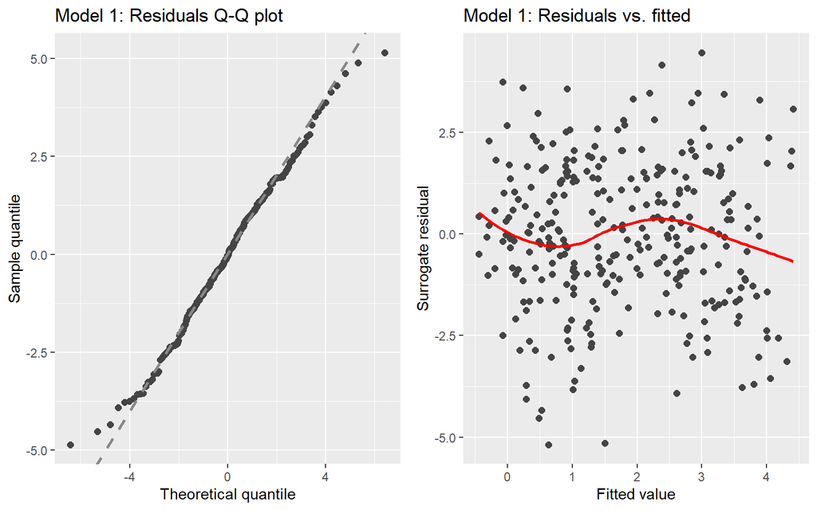

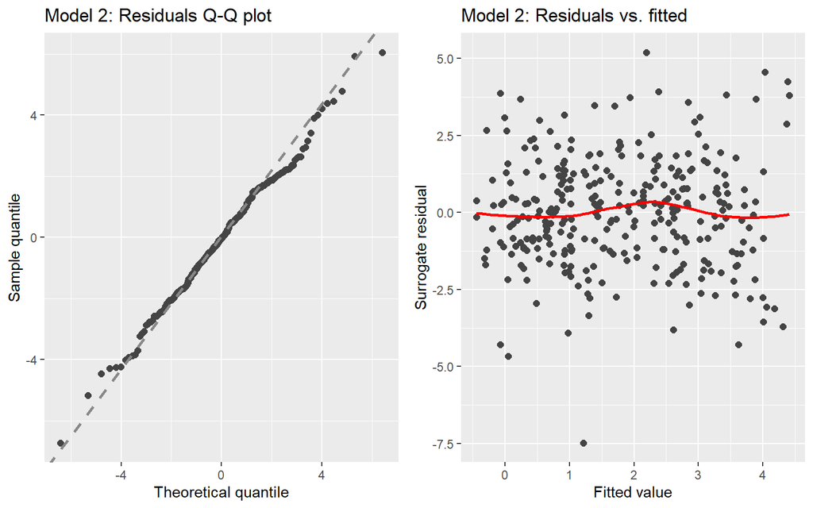

In the Quantile-quantile plots (left) the surrogate residuals seem to be aligned with the normal distribution diagonal trend line, and their distribution seems random in the residuals vs. fitted plot (right). We can conclude that our models are valid.

### Model assumptions

Variation inflation factor (VIF) was calculated for all predictors to detect **multicollinearity**. A VIF>5 can be considered a cause for concern, and VIF=1 is considered optimal. for the first model, one variable had a VIF higher than 5 (interference, VIF=5.5). In the second model, the highest VIF score was 1.77, which is very good. Multicollinearity affects the model’s coefficient estimates and does not affect the model’s prediction ability or reliability, so we can continue in the assessment of this model.

Ordinal regression models assume **Proportional odds**, meaning that the relationship between each pair of outcome groups is the same. The proportional odds assumption was tested using Brant test, and the assumption was met for both models.

## Models’ performance

Prediction Models’ accuracy statistics

|  | Min. | Average | Max. | 2.5% CI | 97.5% CI |
| --- | --- | --- | --- | --- | --- |
| Model 1 | 0.220 | **0.386** | 0.542 | 0.379 | 0.386 |
| Model 2 | 0.203 | **0.383** | 0.559 | 0.380 | 0.387 |

LDA model: prediction vs. reference

|  | Excellent | Very good | Good | Fair | Poor |
| --- | --- | --- | --- | --- | --- |
| Excellent | 8 | 2 | 3 | 2 | 0 |
| Very good | 3 | 8 | 4 | 0 | 1 |
| Good | 1 | 4 | 7 | 4 | 2 |
| Fair | 0 | 1 | 4 | 2 | 0 |
| Poor | 0 | 2 | 1 | 0 | 0 |

We can see that the model managed to classify level “Excellent” relatively well, but performed worse as the levels go up, failing completely to identify level “Poor”. This might be due to the low number of observations for these levels (43 and 17 respectively). When cross-validating a model using a test and train sets, it might fail to detect scarce levels due to insufficient examples in the train set.

## Conclusions

Our models achieved an accuracy rate of 38% at best. In order to fit an accurate and robust prediction model it would be advisable to use a much larger sample size that will ensure there are no sparse cells and provide enough statistical power. In addition, it is recommended to include other variables that are not collinear and which provide discriminative information. Another possibility is to reconsider the outcome variable scale. A 3-level scale may be easier to discern than a 5-level scale.

# 2. Prediction model for Diagnosis

In our cohort there are 2 diagnosis groups: chronic pain condition and JIA. Our outcome variable is binary so we will use logistic regression for our prediction model.  
Subjects with missing data were omitted, and the model was based on 306 subjects.

## Predictors

In order to identify possible predictors, the association between diagnosis and relevant variables was explored. Continuous variables were tested by t-tests, and categorical variables were tested by Chi-squared tests.

|  | Chronic pain condition (N=149) | JIA (N=160) | P-value |
| --- | --- | --- | --- |
| Gender |  |  |  |
| Male | 16 (10.7%) | 50 (31.3%) | <0.001 |
| Female | 133 (89.3%) | 110 (68.8%) |  |
| Age |  |  |  |
| Mean (SD) | 14.8 (1.96) | 12.8 (2.97) | <0.001 |
| Median [Min, Max] | 15.0 [8.00, 18.0] | 13.0 [8.00, 19.0] |  |
| Time from diagnosis(years) |  |  |  |
| Mean (SD) | 1.66 (1.22) | 4.83 (3.64) | <0.001 |
| Median [Min, Max] | 1.00 [0, 7.00] | 4.00 [1.00, 16.0] |  |
| Missing | 1 (0.7%) | 0 (0%) |  |
| Depression |  |  |  |
| Mean (SD) | 11.4 (9.28) | 4.01 (6.73) | <0.001 |
| Median [Min, Max] | 10.0 [0, 32.0] | 0 [0, 32.0] |  |
| Missing | 2 (1.3%) | 0 (0%) |  |
| Fatigue |  |  |  |
| Mean (SD) | 21.2 (12.1) | 9.33 (10.2) | <0.001 |
| Median [Min, Max] | 22.0 [0, 40.0] | 6.50 [0, 40.0] |  |
| Missing | 2 (1.3%) | 0 (0%) |  |
| pain_behavior |  |  |  |
| Mean (SD) | 2.56 (0.973) | 1.78 (0.885) | <0.001 |
| Median [Min, Max] | 2.65 [0.104, 4.29] | 1.77 [0.104, 3.96] |  |
| pain_intensity1 |  |  |  |
| Mean (SD) | 5.08 (2.64) | 2.79 (2.06) | <0.001 |
| Median [Min, Max] | 5.50 [0, 10.0] | 2.50 [0, 9.00] |  |
| Interference |  |  |  |
| Mean (SD) | 17.5 (8.90) | 9.61 (8.52) | <0.001 |
| Median [Min, Max] | 19.0 [0, 32.0] | 8.00 [0, 32.0] |  |
| Missing | 2 (1.3%) | 0 (0%) |  |
| pcs |  |  |  |
| Mean (SD) | 1.77 (1.08) | 0.856 (0.859) | <0.001 |
| Median [Min, Max] | 1.77 [0, 4.00] | 0.615 [0, 4.00] |  |
| wspain |  |  |  |
| Mean (SD) | 20.3 (18.3) | 6.14 (6.81) | <0.001 |
| Median [Min, Max] | 15.0 [0, 61.0] | 4.00 [0, 35.0] |  |

**Pain-related variables** (depression, fatigue, interference, widespread pain, pain behavior, pain intensity and pain catastrophization scale) were all significantly correlated to diagnosis with p-value<0.001.

**Key findings**  
Chronic pain patients had higher scores than JIA patients in all parameters, except for time from diagnosis, which was shorter on average for chronic pain patients. Chronic pain patients were also more likely to be female and older than JIA patients.

The variables were also examined for possible correlations, with diagnosis as a moderator, to detect interactions for the model.

**Time from diagnosis and pain intensity** -The correlation of pain intensity and time from diagnosis is different for JIA and chronic pain patients. It appears that subjects with Chronic pain condition in this cohort are relatively newly diagnosed, and there seems to be a negligible correlation between pain intensity and time from diagnosis for these patients.  
Subjects with JIA in this cohort have been sick for a few years, and there may be a positive correlation between pain intensity greater than 5 and a longer duration of illness.

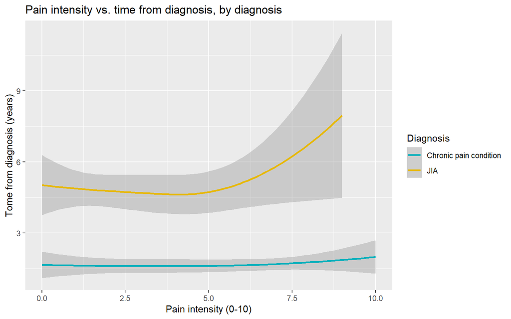

**Gender and depression** - the distribution of depression by Diagnosis is different for males and females. For JIA patients, the distribution for males is more left-skewed compared to females’. For chronic pain patients, the distribution for females is more left-skewed than the males’.

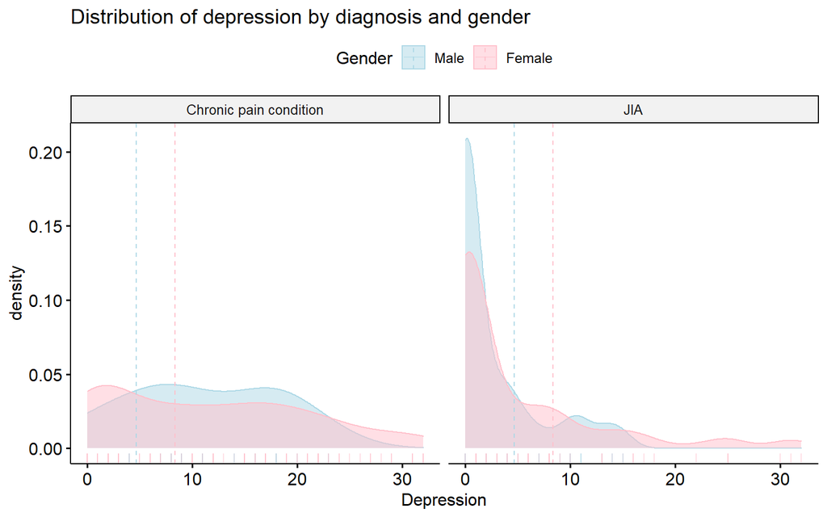

These interactions will be considered in our prediction models.

## Logistic regression models

Several models were built and tested based on these predictors and possible interactions, and their accuracy was assessed. The 2 most accurate models will be presented.  
The first model included demographic variables age, gender, time from diagnosis and predictors depression, widespread pain, fatigue, pain intensity and pain behavior.  
The second model included all these variables and two interactions: an interaction between gender and depression, and between time from diagnosis and pain intensity.

Diagnosis prediction models

|  | Model 1 |  | Model 2 |  |
| --- | --- | --- | --- | --- |
| Predictors | Odds Ratios | p | Odds Ratios | p |
| (Intercept) | 118.20 | **<0.001** | 94.74 | **0.001** |
| Age | 0.74 | **<0.001** | 0.75 | **0.001** |
| Gender female | 0.30 | **0.007** | 0.09 | **0.001** |
| Time from diagnosis | 2.11 | **<0.001** | 3.54 | **<0.001** |
| Depression | 0.91 | **0.002** | 0.77 | **0.002** |
| widespread pain | 0.95 | **0.007** | 0.94 | **0.003** |
| Fatigue | 1.00 | 0.988 | 0.99 | 0.712 |
| Pain intensity | 0.82 | 0.077 | 1.06 | 0.686 |
| Pain behavior | 1.31 | 0.393 | 1.28 | 0.441 |
| Gender female:depression |  |  | 1.21 | **0.023** |
| Pain intensity:time |  |  | 0.90 | **0.017** |
| Observations | 306 |  | 306 |  |
| R<sup>2</sup> Tjur | 0.572 |  | 0.601 |  |
| AIC | 221.133 |  | 214.658 |  |

The second model seems better than the first- is has a lower AIC and a higher $R^2$ Tjur, which is a measure of predictive power for logistic regression models. In addition, the interactions are statistically significant. The models’ assumption were met.  
We will test both models to compare their accuracy in predicting the diagnosis.

## Models’ performance

The models’ performance was tested using ROC curve (Receiver operator characteristics Curve), which is a graphical summary showing the proportion of true positives and false positives at all possible values of probability cutoff. The ROC curve will allow us to identify the optimal threshold value for classification, which is a trade-off between sensitivity and specificity.

To evaluate our models, the data set was split into a training set that was used to build the models, and a test set, that was used to assess our models’ predictive power. This method aids in minimizing model over-fitting.

Model diagnostics

| Model | Accuracy | Specificity | Sensitivity | AUC | ROC threshold |
| --- | --- | --- | --- | --- | --- |
| Model 1 | **83.6%** | 85.6% | 83.8% | 0.930 | 0.512 |
| Model 2 | **90.2%** | 88.4% | 85.6% | 0.939 | 0.491 |

The first model succeeded in predicting the diagnosis in the test data set in 83.6% of the cases.  
The second model had a 90.2% success rate.

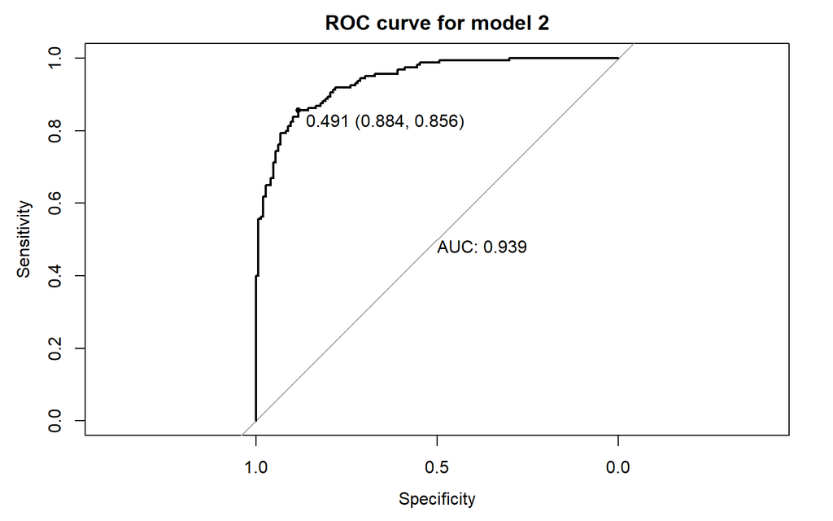

The **optimal threshold** identified by the ROC curve was 0.49.  
**AUC**-Area Under the Curve values range between 0.5 and 1.00. AUC>0.8 is an indication of a good classifier. For our model, the AUC for the train data is 0.939 which is very good.  
The model’s **specificity** is 88.3% and **sensitivity** is 85.6%.  
The model’s **accuracy** is 90.2%.  
**F1 or F score** is another measure of accuracy, balancing the model’s sensitivity and precision. The maximum value of F1 is 1.00, representing perfect precision and sensitivity. Our model’s F1 is 0.897.

The model succeeded in predicting the diagnosis in the test data, which means it is not over-fitted, and its diagnostic parameters are good. The trade-off between sensitivity and specificity can be altered by changing the threshold for classification, depending on how much error we can tolerate in false positives or false negatives.

### Interpretation of the model’s coefficients

Diagnosis prediction model

[output not shown]

# 3. Widespread pain

We explored the associations between widespread pain (number of painful body locations) and the following pain-related variables: depression, fatigue, pain, interference, pain behavior and pain catastrophizing scale, with a possible moderation by diagnosis (chronic pain/ JIA).  
First, we’ll plot widespread pain against our pain-related variables:

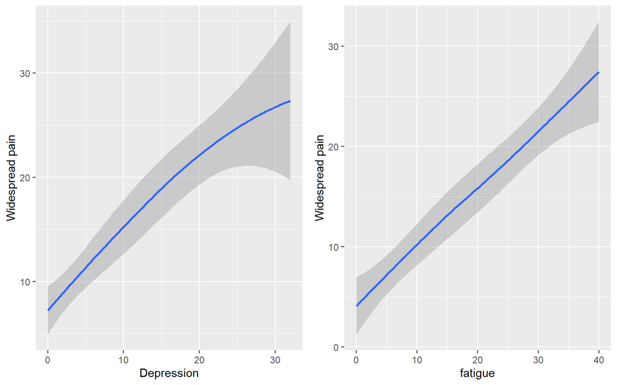

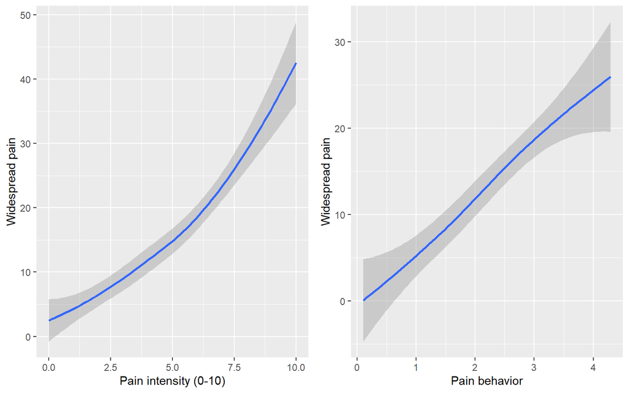

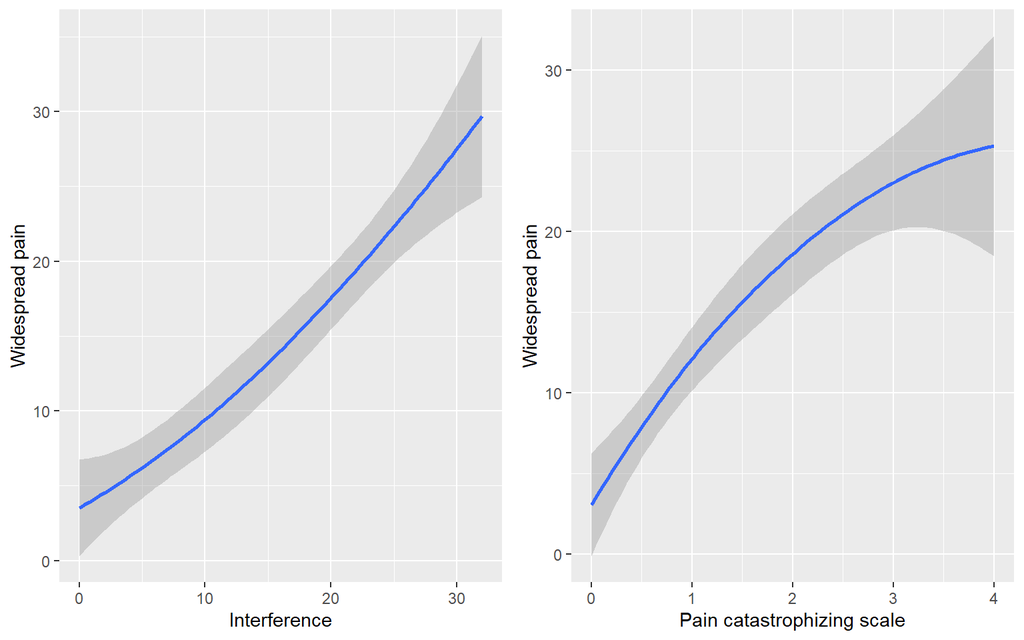

Looking at the correlations between widespread pain and the aforementioned variables, we can note strong positive correlations across the board.  
It should be noted that the confidence intervals (grey-shaded areas) are wider for the higher values of widespread pain, as there were fewer observations there, and so we should be careful if making assumptions based on these areas of the graph.

Since all the graphs appear to be approximately linear, linear regression was used to test these associations. As can be expected, all 6 pain-related variables had a statistically significant correlation to widespread pain with a p-value<0.001 (regression details summarized in table below).  
We can conclude that high widespread pain is correlated to higher depression, fatigue, pain intensity, pain catastrophizing, pain behavior and interference in daily activities.

Summary of correlation testing models

|  | Depression | Fatigue | Pain intensity | Pain behavior | Interference | PCS |
| --- | --- | --- | --- | --- | --- | --- |
| Estimate | 0.71 | 0.58 | 3.33 | 6.52 | 0.78 | 6.23 |
| Std. Error | 0.09 | 0.06 | 0.27 | 0.78 | 0.08 | 0.73 |
| t value | 7.90 | 9.47 | 12.12 | 8.31 | 9.76 | 8.52 |
| Pr(>\|t\|) | 0.00 | 0.00 | 0.00 | 0.00 | 0.00 | 0.00 |

## Moderation by diagnosis

We’ll take a closer look at the correlations between widespread pain and the pain-related variables, with diagnosis as a possible moderator.

### Depression

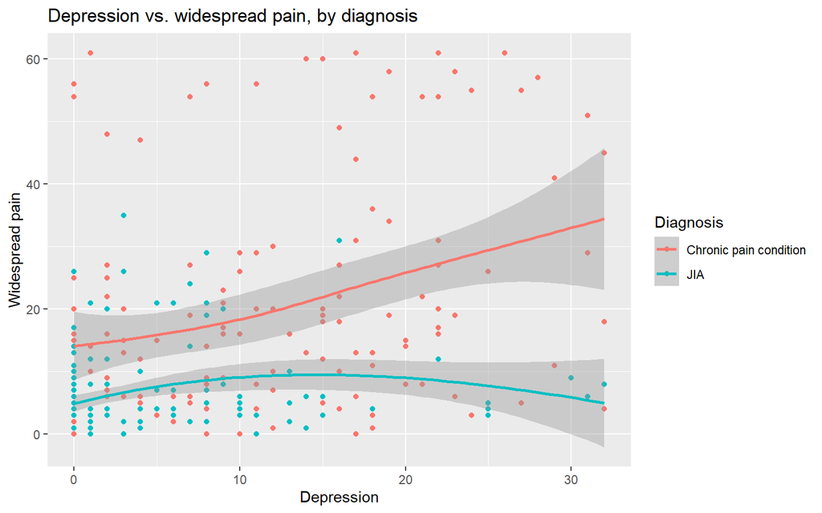

The scatter plot and trend lines show that diagnosis is a possible moderator.  
Chronic pain patients demonstrate a strong positive linear correlation between depression and widespread pain.  
For JIA patients data is scarce for depression levels higher than 20, and the confidence interval is wider. The trend seems square root-like or quadratic.  
Subgroup analysis will allow us to fit the most accurate model for each group by using 2 different formulas. The data set was divided in two based on diagnosis. A linear regression model with a direct correlation was used for the chronic pain group, and a linear model with a square root formula was used for the JIA group.

Chronic pain: Correlation of widespread pain and depression

|  | wspain |  |  |
| --- | --- | --- | --- |
| Predictors | Estimates | std. Error | p |
| (Intercept) | 13.13 | 2.28 | **<0.001** |
| Depression | 0.64 | 0.16 | **<0.001** |
| Observations | 147 |  |  |

**Chronic pain**: The correlation between depression and widespread pain is statistically significant (p-value<0.001), with an estimated slope of 0.64 (SE=0.16). This means that for chronic pain patients, each 1 unit increase in depression score is correlated to 0.64 increase in widespread pain.

JIA:Correlation of widespread pain and depression

|  | wspain |  |  |
| --- | --- | --- | --- |
| Predictors | Estimates | std. Error | p |
| (Intercept) | 4.94 | 0.68 | **<0.001** |
| Depression(sqrt) | 0.96 | 0.34 | **0.005** |
| Observations | 160 |  |  |

**JIA**: The correlation between widespread pain and the square root of depression is statistically significant (p-value=0.005), with an estimated slope of 0.96 (SE=0.34). This means that each x units increase in depression score is correlated to a $0.96*\sqrt(x)$ increase in widespread pain.

### Fatigue

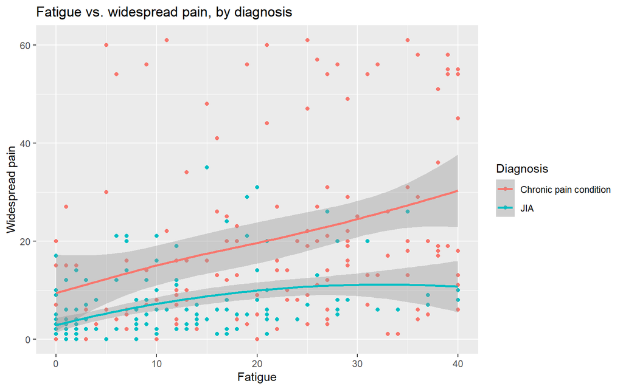

Chronic pain: Correlation of widespread pain and fatigue

|  | wspain |  |  |
| --- | --- | --- | --- |
| Predictors | Estimates | std. Error | p |
| (Intercept) | 9.76 | 2.90 | **0.001** |
| Depression | 0.50 | 0.12 | **<0.001** |
| Observations | 147 |  |  |

JIA: Correlation of widespread pain and fatigue

|  | wspain |  |  |
| --- | --- | --- | --- |
| Predictors | Estimates | std. Error | p |
| (Intercept) | 3.56 | 0.67 | **<0.001** |
| Depression | 0.28 | 0.05 | **<0.001** |
| Observations | 160 |  |  |

The correlation between fatigue and widespread pain is statistically significant for both groups (p-value<0.001), with an estimated slope of 0.5 (SE=0.12) for chronic pain and 0.28 (SE= 0.05) for JIA. Again, the correlation between fatigue and widespread pain is stronger for the chronic group compared to the JIA group.

### Pain intensity

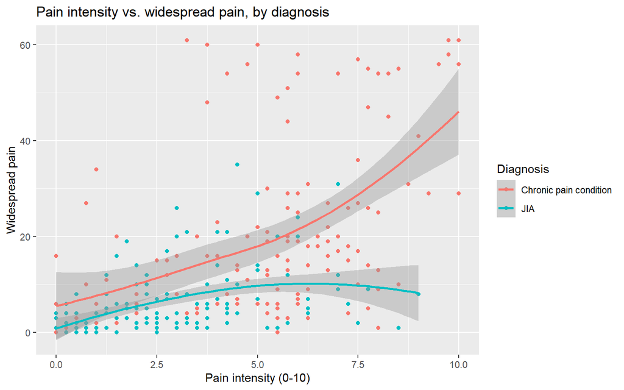

In this graph as well we can see a discrepancy in the trends of chronic pain and JIA.  
The chronic pain group seem to exhibit a quadratic correlation while the JIA group has a square root-like trend. We will use subgroup analysis with appropriate linear regression models to investigate these correlations.

Chronic pain: Correlation of widespread pain and pain intensity

|  | wspain |  |  |
| --- | --- | --- | --- |
| Predictors | Estimates | std. Error | p |
| (Intercept) | 8.00 | 2.09 | **<0.001** |
| Pain intensity^2 | 0.37 | 0.05 | **<0.001** |
| Observations | 149 |  |  |

**Chronic pain**: The correlation between the quadratic formula of pain intensity and widespread pain is statistically significant (p-value<0.001), with an estimated slope of 0.37 (SE=0.05). This means that for chronic pain patients, each x units increase in pain intensity score is correlated to increase of $0.37*X^2$ in widespread pain.

JIA:Correlation of widespread pain and pain intensity

|  | wspain |  |  |
| --- | --- | --- | --- |
| Predictors | Estimates | std. Error | p |
| (Intercept) | 0.06 | 1.11 | 0.954 |
| Pain intensity (sqrt) | 4.05 | 0.67 | **<0.001** |
| Observations | 160 |  |  |

**JIA**: The correlation between widespread pain and the square root of pain intensity is statistically significant (p-value<0.001), with an estimated slope of 4.05 (SE=0.67). This means that each x units increase in pain intensity is correlated to the increase of $4.05*\sqrt(x)$ in widespread pain.

### Pain behavior

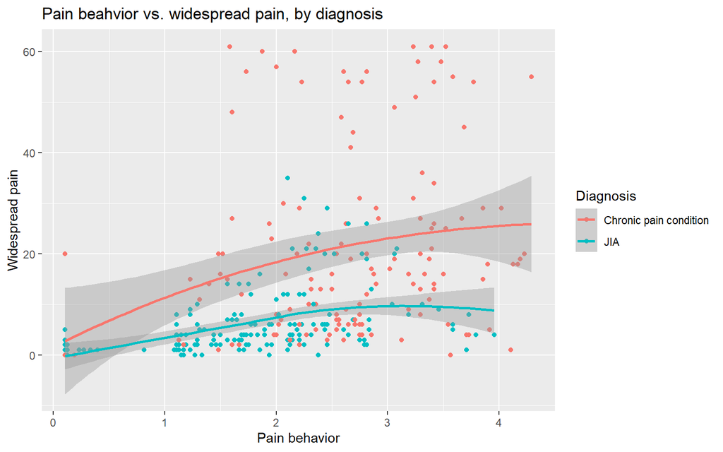

Both groups demonstrate a similar trend in the correlation between pain behavior and widespread pain. The correlation seems square root-like, and was tested with linear regression with an interaction between the square root of pain behavior and diagnosis, and also with a model with an interaction between diagnosis and pain behavior

Correlation of widespread pain and pain behavior, by diagnosis

|  | wspain |  |  | wspain |  |  |
| --- | --- | --- | --- | --- | --- | --- |
| Predictors | Estimates | std. Error | p | Estimates | std. Error | p |
| (Intercept) | -1.72 | 4.30 | 0.689 | 6.23 | 3.00 | **0.038** |
| Diagnosis JIA | -1.21 | 5.46 | 0.825 | -5.95 | 3.78 | 0.116 |
| Pain behavior (sqrt) | 14.17 | 2.69 | **<0.001** |  |  |  |
| Diagnosis:pain behavior (sqrt) | -7.02 | 3.69 | 0.058 |  |  |  |
| Pain behavior |  |  |  | 5.48 | 1.09 | **<0.001** |
| Diagnosis:pain behavior |  |  |  | -2.17 | 1.60 | 0.174 |
| Observations | 309 |  |  | 309 |  |  |

### Interference

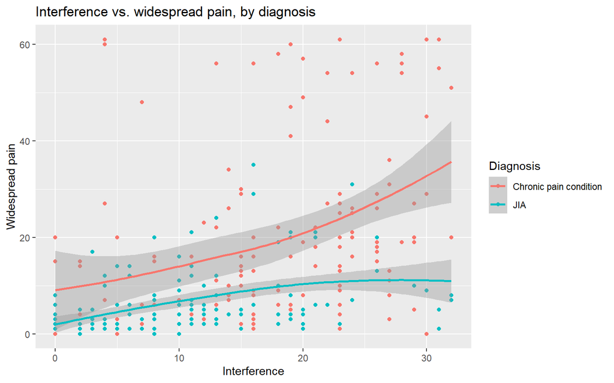

For interference vs. widespread pain the chronic pain group’s trend seems quadratic while the JIA group’s seems square root-like (similarly to pain intensity).  
We fitted 2 linear models with the respective formulas.

Chronic pain: Correlation of widespread pain and interference

|  | wspain |  |  |
| --- | --- | --- | --- |
| Predictors | Estimates | std. Error | p |
| (Intercept) | 10.97 | 2.35 | **<0.001** |
| interference^2 | 0.02 | 0.00 | **<0.001** |
| Observations | 147 |  |  |

**Chronic pain**: The correlation between the quadratic formula of interference and widespread pain is statistically significant (p-value<0.001), with an estimated slope of 0.02 (SE=0.00). This means that for chronic pain patients, each x units increase in pain intensity score is correlated to increase of $0.02*X^2$ in widespread pain.

JIA:Correlation of widespread pain and interference

|  | wspain |  |  |
| --- | --- | --- | --- |
| Predictors | Estimates | std. Error | p |
| (Intercept) | 1.26 | 0.88 | 0.155 |
| interference (sqrt) | 1.88 | 0.28 | **<0.001** |
| Observations | 160 |  |  |

**JIA**: The correlation between widespread pain and the square root of interference is statistically significant (p-value<0.001), with an estimated slope of 1.88 (SE=0.28). This means that each x units increase in pain intensity is correlated to the increase of $1.88*\sqrt(x)$ in widespread pain.

### Pain Catastrophizing Scale

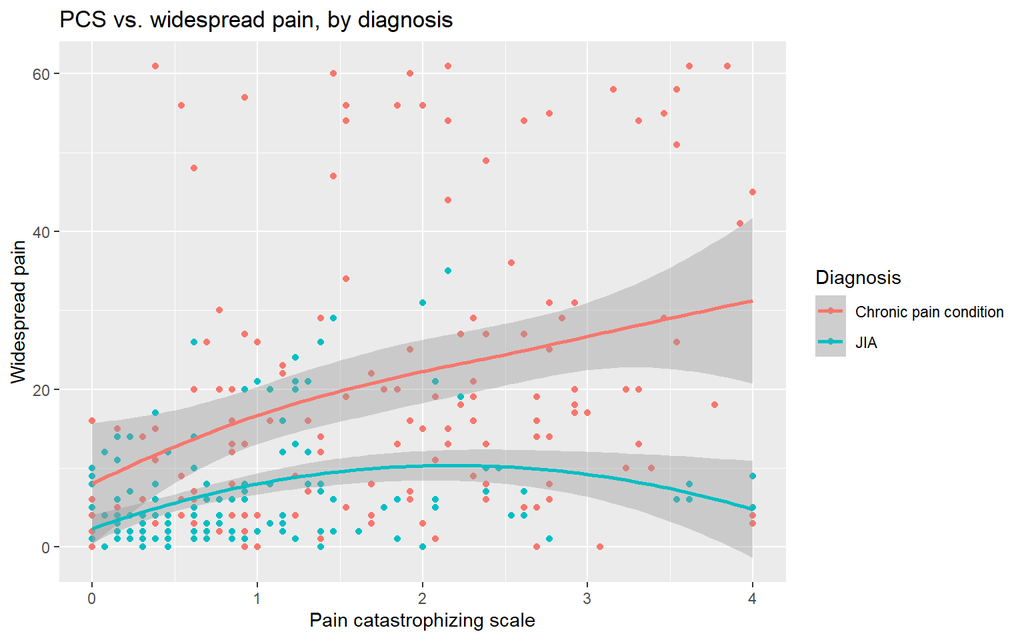

For PCs vs. widespread pain the chronic pain group graph conforms to the square root function. The JIA group’s data was modeled with a quadratic, square root and linear formulas, and the best fit was achieved with the linear formula.

|  | wspain |  |  |
| --- | --- | --- | --- |
| Predictors | Estimates | std. Error | p |
| (Intercept) | 4.74 | 3.79 | 0.213 |
| PCS (sqrt) | 12.57 | 2.85 | **<0.001** |
| Observations | 149 |  |  |

**Chronic pain**: The correlation between widespread pain and the square root of PCS is statistically significant (p-value<0.001), with an estimated slope of 12.57 (SE=2.85). This means that each x units increase in PCS is correlated to the increase of $12.57*\sqrt(x)$ in widespread pain.

JIA:Correlation of widespread pain and PCS

|  | wspain |  |  |
| --- | --- | --- | --- |
| Predictors | Estimates | std. Error | p |
| (Intercept) | 4.22 | 0.73 | **<0.001** |
| PCS | 2.25 | 0.61 | **<0.001** |
| Observations | 160 |  |  |

**JIA**: The correlation between widespread pain and the PCS is statistically significant (p-value<0.001), with an estimated slope of 2.25 (SE=0.61). This means that each 1 unit increase in PCS is correlated to the increase of 2.25 in widespread pain.

## Conclusions and limitations

Summary of correlations between widespread pain and pain-related variables by diagnosis

| Variable | Diagnosis | Slope (SE) | relationship |
| --- | --- | --- | --- |
| Depression | Chronic pain | 0.64 (0.16) | Linear |
|  | JIA | 0.96 (0.34) | Square root |
| Fatigue | Chronic pain | 0.5 (0.12) | Linear |
|  | JIA | 0.28 (0.05) | Linear |
| Pain intensity | Chronic pain | 0.37 (0.05) | Quadratic |
|  | JIA | 4.05 (0.67) | Square root |
| Interference | Chronic pain | 0.02 (0.00) | Quadratic |
|  | JIA | 1.88 (0.28) | Square root |
| PCS | Chronic pain | 12.57 (2.85) | Square root |
|  | JIA | 2.25 (0.61) | Linear |

# Appendix- table summary of comorbidities in the CHOP cohort

Distribution of comorbidites in the CHOP cohort (n=138)

| Total comorbidities per subject | Count |
| --- | --- |
| 0 | 7 |
| 1 | 56 |
| 2 | 29 |
| 3 | 24 |
| 4 | 14 |
| 5 | 6 |
| 6 | 2 |

Prevalence of comorbidites in the CHOP cohort (n=138)

|  | Number of cases |
| --- | --- |
| Kidney_Disease | 0 |
| Blind | 0 |
| Deaf | 0 |
| Cancer | 0 |
| Sickle_Cell | 0 |
| CHD | 0 |
| Cerebral_Palsy | 1 |
| Thyroid | 3 |
| Physical_Assistance | 3 |
| Epilepsy | 3 |
| Hypertension | 4 |
| Diabetes | 4 |
| ADHD | 9 |
| IBS_Crohns | 12 |
| Premature | 15 |
| Overweight | 17 |
| Mental_Health | 35 |
| Asthma | 37 |
| Rheumatic_Disease | 53 |
| Chronic_Pain | 88 |
| total | 284 |